# COVID-19 vaccine coverage in Harford County, MD

(Page updated at 2021-03-23 18:03:49)  
Data as of: 03/23/2021, from Maryland Department of Health. See Annex for detailed note about the data.

## 1. Coverage: overall and by background characteristics

### 1.1 One or more doses

COVID-19 vaccine coverage, one or more doses (number of people and percent of population): cumulative and past 7 days

| group | count | coverage | count7day | coverage7day |
| --- | --- | --- | --- | --- |
| Total | 70983 | 28 | 6612 | 2.6 |
| Non-Hispanic White | 52846 | 28 | 4535 | 2.4 |
| Non-Hispanic Black | 6058 | 17 | 858 | 2.4 |
| Non-Hispanic Asian | 2058 | 28 | 293 | 4.0 |
| Hispanic | 1554 | 13 | 204 | 1.7 |
| Female | 42778 | 33 | 3451 | 2.6 |
| Male | 28179 | 23 | 3155 | 2.5 |
| 75+ | 13065 | 75 | 670 | 3.8 |
| 65-74 | 17357 | 70 | 1623 | 6.5 |
| White 65+ | 23794 | 66 | 1710 | 4.7 |
| Black 65+ | 2026 | 36 | 285 | 5.0 |
| Hispanic 65+ | 365 | 66 | 45 | 8.1 |

### 1.2 By status

COVID-19 vaccine coverage by status (number of people): complete, waiting adequate (<28 days), waiting late (28-41 days), vs. late

| group | total | complete | waiting1 | waiting2 | late |
| --- | --- | --- | --- | --- | --- |
| Total | 70983 | 36875 | 31320 | 1251 | 1514 |
| Non-Hispanic White | 52846 | 28711 | 22394 | 909 | 813 |
| Non-Hispanic Black | 6058 | 2664 | 3154 | 84 | 155 |
| Non-Hispanic Asian | 2058 | 1098 | 903 | 27 | 30 |
| Hispanic | 1554 | 784 | 711 | 35 | 23 |
| Female | 42778 | 23778 | 17298 | 723 | 966 |
| Male | 28179 | 13091 | 14002 | 528 | 548 |
| 75+ | 13065 | 6731 | 5634 | 194 | 503 |
| 65-74 | 17357 | 6911 | 9790 | 407 | 240 |
| White 65+ | 23794 | 11144 | 11796 | 472 | 372 |
| Black 65+ | 2026 | 621 | 1317 | 29 | 58 |
| Hispanic 65+ | 365 | 141 | 210 | 11 | 3 |

Note:  
1. Complete: either two doses of Moderna or Pfizer, or one dose of J&J vaccine  
2. Sum of the number of complete, waiting1, waiting2, and late may not be same with the total number of people, due to a small number of cases with missing information on manufacture and/or vaccination date.

COVID-19 vaccine coverage by status (percent of population): complete, waiting adequate (<28 days), waiting late (28-41 days), vs. late

| group | pcttotal | pctcomplete | pctwaiting1 | pctwaiting2 | pctlate |
| --- | --- | --- | --- | --- | --- |
| Total | 28 | 14 | 12 | 0 | 0.6 |
| Non-Hispanic White | 28 | 15 | 12 | 0 | 0.4 |
| Non-Hispanic Black | 17 | 7 | 9 | 0 | 0.4 |
| Non-Hispanic Asian | 28 | 15 | 12 | 0 | 0.4 |
| Hispanic | 13 | 6 | 6 | 0 | 0.2 |
| Female | 33 | 18 | 13 | 1 | 0.7 |
| Male | 23 | 10 | 11 | 0 | 0.4 |
| 75+ | 75 | 39 | 32 | 1 | 2.9 |
| 65-74 | 70 | 28 | 39 | 2 | 1.0 |
| White 65+ | 66 | 31 | 33 | 1 | 1.0 |
| Black 65+ | 36 | 11 | 23 | 1 | 1.0 |
| Hispanic 65+ | 66 | 25 | 38 | 2 | 0.5 |

Note:  
1. Complete: either two doses of Moderna or Pfizer, or one dose of J&J vaccine

## 2. Coverage by zipcode among Harford county residents

### 2.1 One or more doses

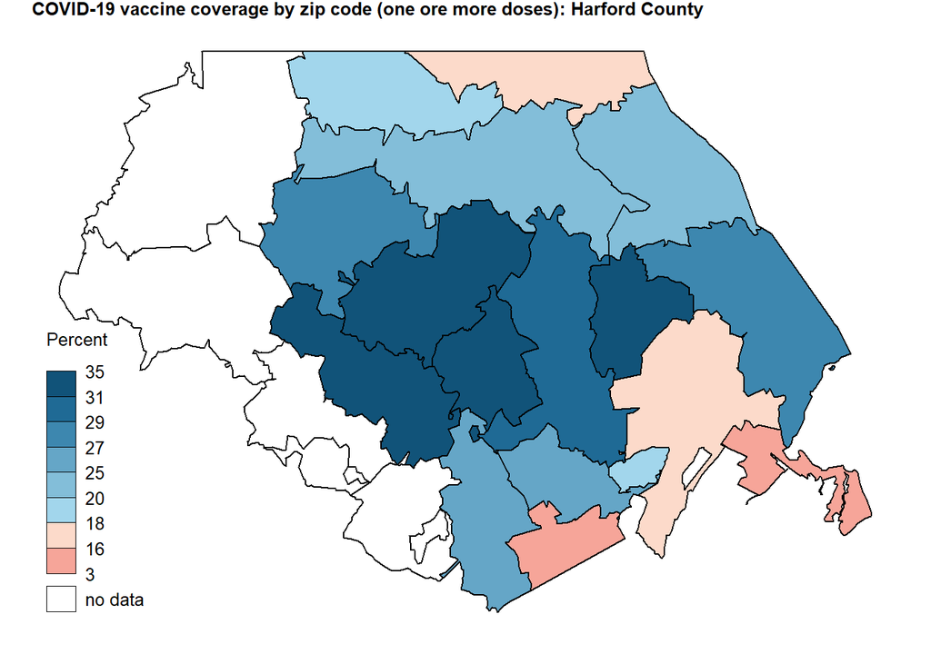

COVID-19 vaccine coverage, one or more doses by zip code (number of people and percent of population): cumulative and past 7 days

| ZIP_CODE | count | coverage | count7day | coverage7day |
| --- | --- | --- | --- | --- |
| 21001 | 4238 | 17 | 529 | 2.1 |
| 21005 | 92 | 3 | 18 | 0.6 |
| 21009 | 7421 | 25 | 782 | 2.6 |
| 21014 | 11569 | 32 | 883 | 2.4 |
| 21015 | 8567 | 29 | 784 | 2.7 |
| 21017 | 1328 | 19 | 132 | 1.9 |
| 21028 | 872 | 31 | 93 | 3.3 |
| 21034 | 699 | 20 | 70 | 2.0 |
| 21040 | 3361 | 14 | 568 | 2.4 |
| 21047 | 4233 | 35 | 333 | 2.7 |
| 21050 | 5668 | 31 | 439 | 2.4 |
| 21078 | 4965 | 27 | 426 | 2.3 |
| 21084 | 2098 | 28 | 201 | 2.6 |
| 21085 | 4036 | 25 | 434 | 2.7 |
| 21132 | 596 | 18 | 64 | 2.0 |
| 21154 | 1377 | 24 | 133 | 2.3 |
| 21160 | 461 | 16 | 46 | 1.6 |

### 2.2 Complete doses

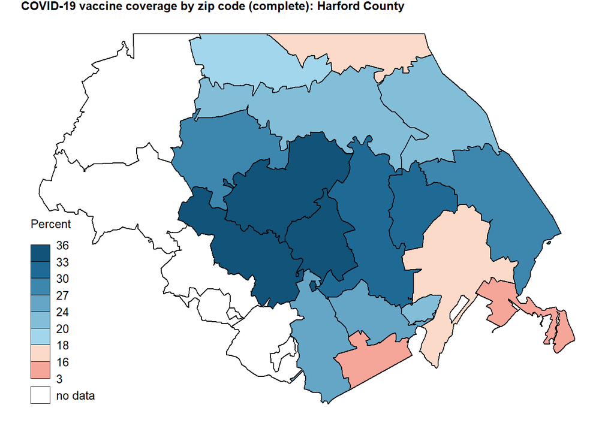

Note:  
1. Complete: either two doses of Moderna or Pfizer, or one dose of J&J vaccine

| ZIP_CODE | count | coverage | count7day | coverage7day |
| --- | --- | --- | --- | --- |
| 21001 | 3873 | 16 | 304 | 1.2 |
| 21005 | 75 | 3 | 3 | 0.1 |
| 21009 | 7732 | 26 | 284 | 0.9 |
| 21014 | 12623 | 35 | 403 | 1.1 |
| 21015 | 9121 | 31 | 300 | 1.0 |
| 21017 | 1413 | 20 | 56 | 0.8 |
| 21028 | 846 | 30 | 33 | 1.2 |
| 21034 | 682 | 20 | 15 | 0.4 |
| 21040 | 2936 | 12 | 169 | 0.7 |
| 21047 | 4441 | 36 | 168 | 1.4 |
| 21050 | 6067 | 33 | 207 | 1.1 |
| 21078 | 4996 | 27 | 165 | 0.9 |
| 21084 | 2056 | 27 | 86 | 1.1 |
| 21085 | 3883 | 24 | 183 | 1.1 |
| 21132 | 597 | 18 | 21 | 0.6 |
| 21154 | 1330 | 23 | 63 | 1.1 |
| 21160 | 502 | 17 | 18 | 0.6 |

Note:  
1. Complete: either two doses of Moderna or Pfizer, or one dose of J&J vaccine

## Annex: Detailed description of the data

See [GitHub](https://github.com/yoonjoung/COVID19_FlattenedCurve) for data, code, and more information. For typos, errors, and questions, contact me at [www.isquared.global](https://www.iSquared.global/YJ).

*Making Data Delicious, One Byte at a Time*